# Time Series

Lecture 11

February 18, 2026

# Review

## GLMs

- Generalized Linear Models: use linear models to represent alternative distributional assumptions.
- $$y_i \sim \mathcal{D}(\theta), \quad f(\theta) = \sum_j \beta_j x_i^j$$
- Focus on logistic and Poisson regressions.
- Can be more challenging to interpret coefficients.

# Time Series

## Time Series and Environmental Data

Many environmental datasets involve **time series**: repeated observations over time:

$$X = \{X_t, X_{t+h}, X_{t+2h}, \ldots, X_{t+nh}\}$$

More often: ignore sampling time in notation,

$$X = \{X_1, X_2, X_3, \ldots, X_n\}$$

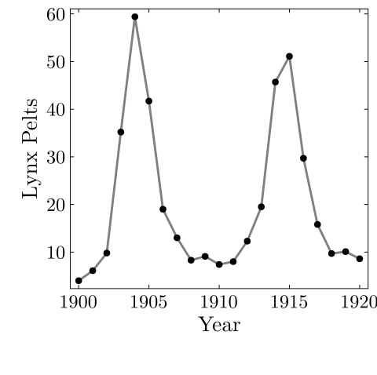

Figure 1: Example of time series; trapped lynx populations in Canada.

## Spectral Analysis

Often time series have **periodic** components. Can recover these using regression:
$$y_t = A \cos(\omega t) + B \sin(\omega t) + C + \varepsilon_t, \qquad \varepsilon \sim N(0, \sigma^2).$$

## Tide Gauge Data

```julia
function load_data(fname)
    date_format = "yyyy-mm-dd HH:MM"
    # this uses the DataFramesMeta package -- it's pretty cool
    return @chain fname begin
        CSV.File(; dateformat=date_format)
        DataFrame
        DataFrames.rename(
            "Time (GMT)" => "time", "Predicted (m)" => "harmonic", "Verified (m)" => "gauge"
        )
        @transform :datetime = (Date.(:Date, "yyyy/mm/dd") + Time.(:time))
        select(:datetime, :gauge, :harmonic)
        @transform :weather = :gauge - :harmonic
        @transform :month = (month.(:datetime))
    end
end

dat = load_data("data/surge/norfolk-hourly-surge-2015.csv")

p1 = plot(dat.datetime, dat.gauge; ylabel="Gauge Measurement (m)", label="Observed", legend=:topleft, xlabel="Date/Time", bottom_margin=5mm, left_margin=5mm, right_margin=5mm, size=(1100, 500))
```

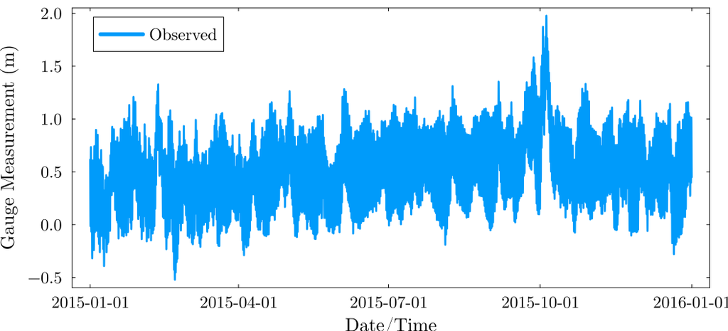

Figure 2: 2015 tide gauge data from the Norfolk, VA tide gauge.

## How To Identify Interesting Periods

**Spectral analysis**: Based on Fourier decomposition to switch between **time domain** and **frequency domain**.

## Estimating Fourier Coefficients

Let $\omega_j = 2\pi j / T$. Then:

$$\begin{aligned}
\hat{A} &= \frac{2}{T} \sum_t y_t \cos(\omega_j t) \\
\hat{B} &= \frac{2}{T} \sum_t y_t \sin(\omega_j t) \\
\hat{C} &= \bar{Y} = \frac{1}{T} \sum_t y_t.
\end{aligned}$$

## Periodogram

Can then define the **periodogram**
$$I_T(\omega) = \frac{1}{2\pi T} \left|\sum_{t=1}^T y_t e^{i\omega t}\right|^2.$$

Larger values of $I_T$ mean those frequencies contribute more to the overall signal.

## Periodogram: Tide Gauge

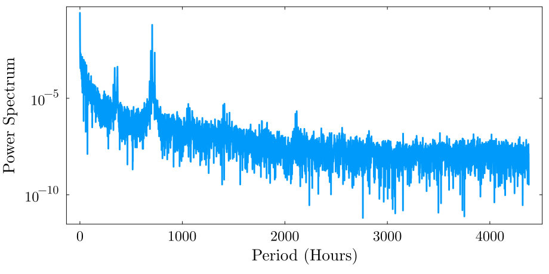

Figure 3: Periodogram for the NOrfolk Tide Gauge Data

```julia
T = nrow(dat) # get number of samples (this is hourly in this case), so 8760
ps = DSP.periodogram(dat.gauge; fs=T) # compute periodogram with T sampling frequency
plot(ps.freq, ps.power, xlabel="Period (Hours)", ylabel="Power Spectrum", legend=false, linewidth=3, yaxis=:log)
```

The biggest spikes are at period 0 (no period; this is just a drift without harmonic behavior) and period 711 (roughly 30 days; aligns with the lunar cycle).

Sometimes periodograms are computed with respect to *frequency*, rather than *period*: recover period by multiplying by the sampling frequency.

# Autocorrelation

## Temporal Dependence

**Dependence**: History or sequencing of the data matters

$$p(y_t) = f(y_1, \ldots, y_{t-1})$$

Serial dependence captured by **autocorrelation**:

$$\varsigma(i) = \rho(y_t, y_{t-i}) = \frac{\text{Cov}[y_t, y_{t-i}]}{\mathbb{V}[y_t]}$$

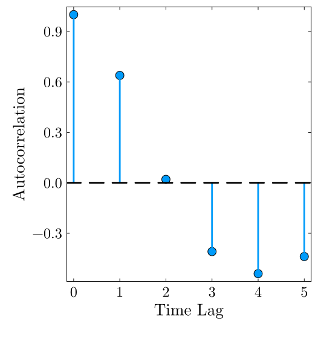

Figure 4: Autocorrelation for the Lynx data.

## Stationarity

**I.I.D. Data**: All data drawn from the same distribution, $y_i \sim \mathcal{D}$.

Equivalent for time series $\mathbf{y} = \{y_t\}$ is **stationarity**.

- **Strict stationarity**: $\{y_t, \ldots, y_{t+k-1}\} \sim \mathcal{D}$ for all $t$.
- **Weak stationarity**: $\mathbb{E}[X_1] = \mathbb{E}[X_t]$ and $\text{Cov}(X_1, X_k) = \text{Cov}(X_t, X_{t+k-1})$ for all $t, k$.

## Stationary vs. Non-Stationary Series

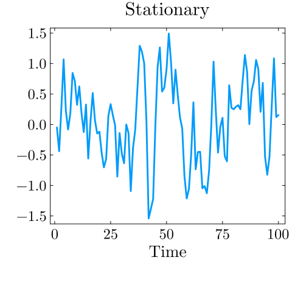

(a) Stationary vs. Non-stationary time series

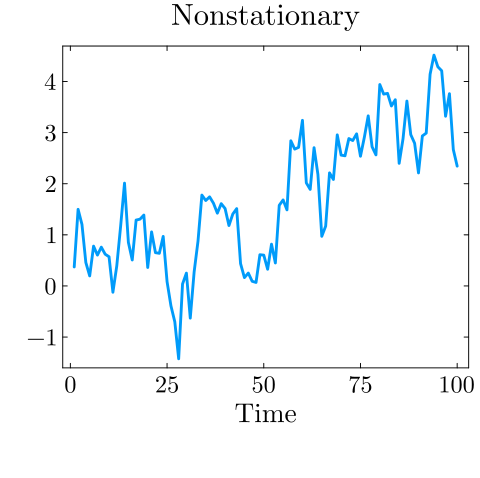

(b)

Figure 5

## Autocorrelation

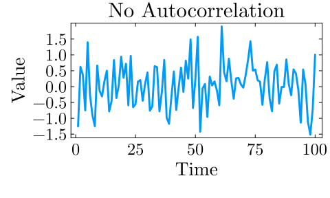

(a) Lag-1 autocorrelation for an AR model and Gaussian noise.

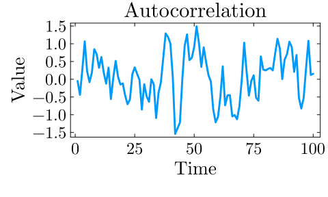

(b)

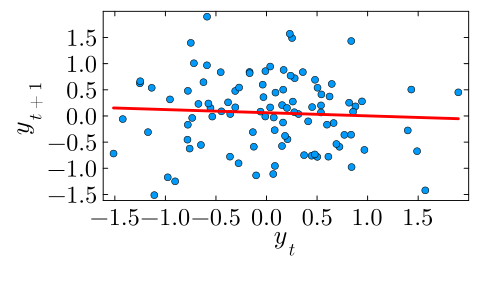

(c)

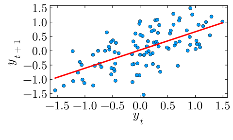

(d)

Figure 6

## Autocorrelation and Linear Regression

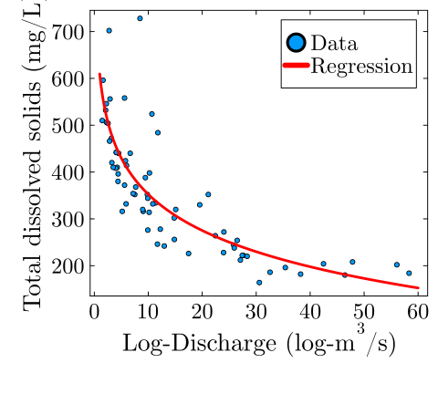

(a) Autocorrelation of linear regression residuals

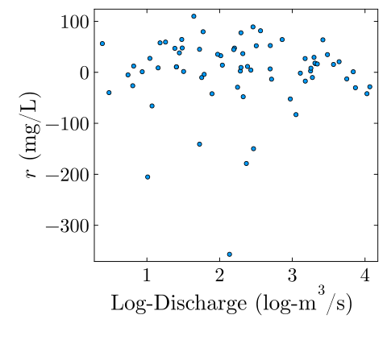

(b)

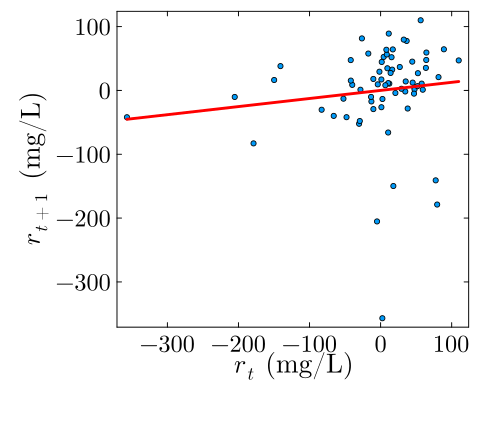

(c)

Figure 7

```julia
# tds_riverflow_loglik: function to compute the log-likelihood for the tds model
# θ: vector of model parameters (coefficients β₀ and β₁ and stdev σ)
# tds, flow: vectors of data
tds = let
    fname = "data/tds/cuyaTDS.csv" # CHANGE THIS!
    tds = DataFrame(CSV.File(fname))
    tds[!, [:date, :discharge_cms, :tds_mgL]]
end

function tds_riverflow_loglik(θ, tds, flow)
    β₀, β₁, σ = θ # unpack parameter vector
    μ = β₀ .+ β₁ * log.(flow) # find mean
    ll = sum(logpdf.(Normal.(μ, σ), tds)) # compute log-likelihood
    return ll
end

lb = [0.0, -1000.0, 1.0]
ub = [1000.0, 1000.0, 100.0]
θ₀ = [500.0, 0.0, 50.0]
optim_out = Optim.optimize(θ -> -tds_riverflow_loglik(θ, tds.tds_mgL, tds.discharge_cms), lb, ub, θ₀)
θ_mle = optim_out.minimizer; digits=0

x = 1:0.1:60
μ = θ_mle[1] .+ θ_mle[2] * log.(x)
p1 = scatter(tds.discharge_cms, tds.tds_mgL, markersize=3, xlabel=L"Log-Discharge (log-m$^3$/s)", ylabel="Total dissolved solids (mg/L)", label="Data", size=(500, 450))
plot!(p1, x, μ, linewidth=3, color=:red, label="Regression")

pred = θ_mle[1] .+ θ_mle[2] * log.(tds.discharge_cms)
resids = pred - tds.tds_mgL
p2 = scatter(log.(tds.discharge_cms), resids, markersize=3, ylabel=L"$r$ (mg/L)", xlabel=L"Log-Discharge (log-m$^3$/s) ", size=(500, 450))
p3 = scatter(resids[1:end-1], resids[2:end], markersize=3, ylabel=L"$r_{t+1}$ (mg/L)", xlabel=L"$r_t$ (mg/L)", size=(500, 450))
T = nrow(tds)
rlr = lm([ones(T-1) resids[1:end-1]], resids[2:end])
rpred = predict(rlr, [ones(T-1) resids[1:end-1]])
plot!(p3, resids[1:end-1], rpred, linewidth=3, color=:red)

display(p1)
display(p2)
display(p3)
```

Residuals have autocorrelation 0.13.

# Autoregressive (AR) Models

## AR(1) Models

AR(p): (autoregressive of order $p$):

$$\begin{align*}
y_t &= \alpha + \rho y_{t-1} + \varepsilon_t \\
\varepsilon &\sim \mathcal{D}(\theta) \\
y_0 &\sim \mathcal{G}(\psi)
\end{align*}$$

$\mathbb{E}[\varepsilon] = 0$, $\text{cor}(\varepsilon_i, \varepsilon_j) = 0$, $\text{cor}(\varepsilon_i, y_0) = 0$

## Uses of AR Models

AR models are commonly used for **prediction**: bond yields, prices, electricity demand, short-run weather.

But may have little explanatory power: what **causes** the autocorrelation?

## AR(1) Models

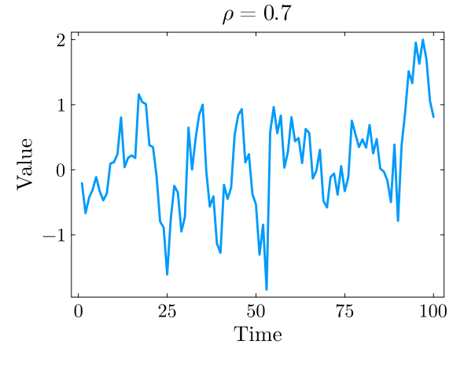

(a) AR(1) model

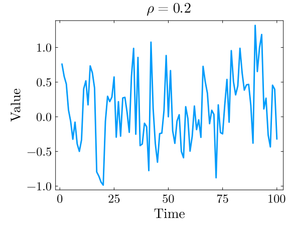

(b)

Figure 8

## Simulating AR(1) Data

- Draw an initial $y_0 \sim \mathcal{G}(\psi)$
- For $t \geq 1$:
  - Draw $\varepsilon_t \sim \mathcal{D}(\theta)$
  - Set $y_t = \alpha + \rho y_{t-1} + \varepsilon_t$

## Diagnosing Autocorrelation

Plot $\varsigma(i)$ over a series of lags.

Data generated by an AR(1) with $\rho = 0.7$.

**Notice**: No explicit higher order autocorrelation, but $\varsigma(2) > 0$.

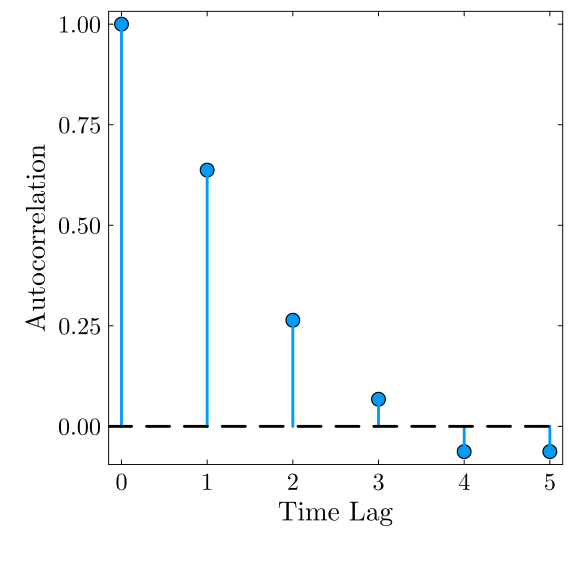

Figure 9: Autocorrelation Function

## “Memory” of Autocorrelation

$$\begin{aligned}
y_t &= \alpha + \rho y_{t-1} + \varepsilon_t \\
&= \alpha + \rho \left(\alpha + \rho y_{t-2} + \varepsilon_{t-1}\right) + \varepsilon_t \\
&= \alpha + \rho \alpha + \rho^2 y_{t-2} + \rho \varepsilon_{t-1} + \varepsilon_t \\
&= \ldots \\
&= \alpha \sum_{k=0}^{t-1} \rho^k + \rho^t y_0 + \sum_{k=0}^{t-1} \varepsilon_{t-k} \rho^k
\end{aligned}$$

## Partial Autocorrelation

Can isolate $\varsigma(i)$ independent of $\varsigma(i-k)$ through *partial autocorrelation*.

Typically estimated through regression,
$$y = \sum_{k=1}^i \varsigma(i-k) y_{i-k}.$$

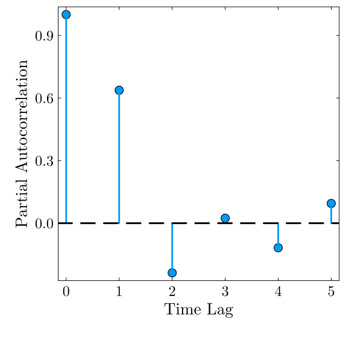

Figure 10: Partial autocorrelation Function

# Key Points

## Key Points

- Time series exhibit serial dependence (autocorrelation)
- AR(1): autoregressive model with explicit lag-1 dependence.
- AR(1) is **stationary** if and only if $|\rho| < 1$.
- In general, AR models useful for forecasting, pretty useless for explanation.
- **Similar concepts in spatial data**: spatial correlation (distance/adjacency vs. time), lots of different models.

## For More On Time Series

**Courses**

- STSCI 4550/5550 (Applied Time Series Analysis),
- CEE 6790 (heavy focus on spectral analysis and signal processing)

**Books**

- Shumway & Stoffer (2025)
- Hyndman & Athanasopoulos (2021)
- Durbin & Koopman (2012)
- Banerjee et al. (2011)
- Cressie & Wikle (2011)

# Upcoming Schedule

## Next Classes

**Friday**: AR(1) Inference

**Next Week**: Extreme Values (Theory and Models)

**Next Unit**: Hypothesis Testing, Model Evaluation, and Comparison

## Assessments

**HW2**: Due Friday at 9pm.

**Exercises**: Available after class (will include GLMs + time series).

**HW3**: Assigned on 3/2, due 3/13.

# References

## References (Scroll For Full List)

Banerjee, S., Carlin, B. P., & Gelfand, A. E. (2011). *Hierarchical modeling and analysis for spatial data, second edition* (2nd ed.). Philadelphia, PA: Chapman & Hall/CRC. https://doi.org/10.1201/b17115

Cressie, N., & Wikle, C. K. (2011). *Statistics for Spatio-Temporal Data*. Hoboken, NJ: Wiley.

Durbin, J., & Koopman, S. J. (2012). *Time series analysis by state space methods* (2nd ed.). London, England: Oxford University Press. https://doi.org/10.1093/acprof:oso/9780199641178.001.0001

Hyndman, R. J., & Athanasopoulos, G. (2021). *Forecasting: Principles and Practice (3rd ed)*. Melbourne, Australia: OTexts. Retrieved from https://otexts.com/fpp3/

Shumway, R. H., & Stoffer, D. S. (2025). *Time series analysis and its applications*. Springer.